# Final Exam Review

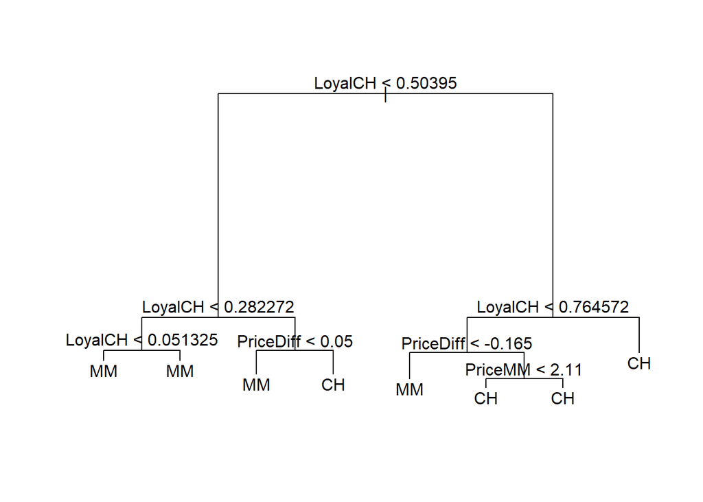

  ```r
  # part d
  plot(tree_oj)
  text(tree_oj, pretty=0)
  ```

  ```r
  # part e
  tree.pred = predict(tree_oj, testOJ, type='class')
  table(tree.pred, testOJ$Purchase)
  ```

  ```
  ##
  ## tree.pred  CH  MM
  ##        CH 132  34
  ##        MM  20  84
  ```

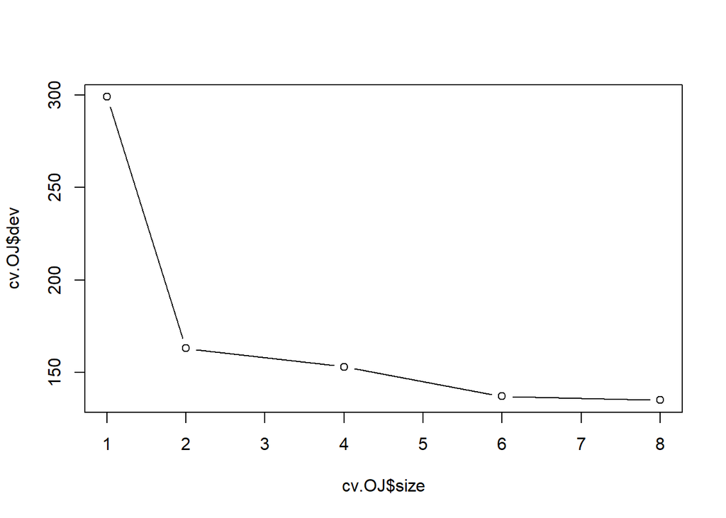

  ```r
  # part f
  set.seed(3)
  cv.OJ = cv.tree(tree_oj, FUN=prune.misclass)
  plot(cv.OJ$size, cv.OJ$dev, type="b")
  ```

  ```r
  # part g
  index = which.min(cv.OJ$dev)
  cv.OJ$size[index]
  ```

  ```
  ## [1] 8
  ```

  ```r
  # part h
  prune.OJ = prune.misclass(tree_oj, best=7)
  summary(prune.OJ)
  ```

  ```
  ##
  ## Classification tree:
  ## tree(formula = Purchase ~ ., data = trainOJ, split = c("deviance"))
  ## Variables actually used in tree construction:
  ## [1] "LoyalCH"   "PriceDiff" "PriceMM"
  ## Number of terminal nodes:  8
  ## Residual mean deviance:  0.7321 = 579.8 / 792
  ## Misclassification error rate: 0.1525 = 122 / 800
  ```

  ```r
  # part j
  tree.pred.prune = predict(prune.OJ, testOJ, type='class')
  table(tree.pred.prune, testOJ$Purchase)
  ```

  ```
  ##
  ## tree.pred.prune  CH  MM
  ##              CH 132  34
  ##              MM  20  84
  ```

### Tree-cost complexity pruning

- What is it?
  - “pruning” is a technique used to control the size of a decision tree by penalizing the complexity of the tree
  - the goal is to find a balance between the simplicity of the tree and its ability to accurately predict unseen data
- Implementation?
  - during the construction of a decision tree, each internal node is assigned a cost based on the complexity parameter $\alpha$
  - the cost complexiting parameter, alpha, is a tuning parameter that controls the trade off between tree complexity and goodness of fit. a higher alpha leads to simpler trees
  - the pruning process involves iteratively removing the nodes with the highest cost until the optimal tree size is reached
- Tying into Bias-Variance Tradeoff
  - High Bias (Underfitting):
    - a highly pruned decision tree (smaller tree) corresponds to high bias
    - pruning helps reduce complexity, but if done excessively, it may result in a model that is too simple and unable to capture the underlying patterns in the data
  - High Variance (Overfitting):
    - an unpruned decision tree (larger tree) corresponds to high variance
    - without pruning, a decision tree can become overly complex and fit the training data too closely, leading to poor generalization to new, unseen data

### Classification trees

- very similar to regression tree, except the response is categorical
- predict each observation belongs to the most commonly occurring class of training observations in the region to which it belongs
- recursive binary splitting to grow classification tree
- classification error rate
  - alternative to RSS
  - fraction of training observations that don’t belong to the most common class: $E = 1-max_k (\hat{p}_{mk})$, $\hat{p}_{mk}$ is the portion of training observations in the mth region that are from the kth class
- Gini Index (node purity)
  - $G = \sum_{k=1}^K \hat{p}_{mk} (1-\hat{p}_{mk})$ can be interpreted as a measure of total variance across K classes
  - small values of Gini index are better
  - if all $\hat{p}_{mk}$ are approximately 0 or 1, gini index is small value
  - small value of Gini index says that a node contains predominantly observations from a single class
- Entropy
  - $D = - \sum_{k=1}^K \hat{p}_{mk} log(\hat{p}_{mk})$
  - D is always positive
  - entropy takes on small value if $\hat{p}_{mk}$ all near 0 and 1
  - entropy will take on small value if the mth node is pure